# Japanese learning (Pareto Law Application and Validation)

In this project, the purpose was to verified the Pareto Principle : 20% of the causes lead to 80% of the results.

In my case, for a Netflix serie, I wanted to see if focusing on 20% of the most used words could lead to 80% of understanding. I used different approaches : see within the serie itself with the repartition of words, compare to the offical Japanese exam vocabulary, and the offical list of most used Kanji (jôyô kanji).

Tools used :

- Simple web-scraping and CSV reports : sources -> Netflix, dondon.media, wikipedia
- Power Query and Excel
- SQL : On MySQL Workbench and in Python with Magic SQL
- Python
- Power BI

Librairies/Conectors used :

- import pandas
- import mysql.connector
- %load_ext sql
- import csv
- from collections import defaultdict
- import MeCab (wrapper for the MeCab morphological analyzer for Japanese text)
- import regex

Steps :

1. Get the data and store it
2. Clean the data in MySQL (a bit of cleaning is done in step 3 too)
3. Analysis of the word occurences
4. Comparison with the vocabulary of the JLPT
5. Comparison with the Jôyô Kanji list
6. Visualization

## Conclusion of the project : The Pareto Principle is validated

**This data analysis illustrates well the Pareto Principle 80-20 : about 20% of the words allow to understand 80% of the words that appear. However, it does not mean necessarily to understand 80% of the meaning as sometimes 100% of the words are necessary to understand a text. Furthermore, depending on the serie and the context, these list of words and Kanji can vary. It is still a good approach to focus on what's important to understand a large part of words in a serie instead of trying to learn everything at once.**

### Quick explaination of the Japanese writing system :

Kanji, hiragana, and katakana are three different writing systems used in the Japanese language. Here's a brief explanation of each:

1. Kanji (learning Japanese myself, this is for me the hardest part of this language): Kanji are characters borrowed from Chinese. They are logographic characters that represent meanings and can sometimes have multiple pronunciations. Kanji characters can represent whole words or parts of words, and they are used for nouns, verbs, adjectives, and more. They convey the core meaning of a word and are an essential part of written Japanese. Kanji characters can be complex and have various stroke orders.

[figure not shown]

2. Hiragana: Hiragana is a phonetic writing system consisting of 46 characters. Each hiragana character represents a distinct sound in the Japanese language. Hiragana is used to write grammatical elements, particles, verb and adjective endings, and native Japanese words. It is considered the basic script for beginner learners and is used extensively in everyday writing, such as informal conversations, children's books, and personal diaries.
3. Katakana: Katakana is another phonetic writing system with 46 characters. Like hiragana, each katakana character represents a distinct sound. Katakana is primarily used for writing loanwords, foreign names, onomatopoeic words, technical terms, and emphasis. It has a more angular appearance compared to hiragana, with straighter lines and fewer curved strokes. Katakana is commonly seen in signage, advertisements, and words borrowed from languages other than Chinese.

[figure not shown]

In written Japanese, all three scripts—kanji, hiragana, and katakana—can be used together. This writing system is known as "kanji kana majiri bun" and allows for a flexible and comprehensive representation of the Japanese language.

One difficulty for my project was that there is no blank space in Japanese. All the words are side to side (for instance : IwanttolearnJapanese). I had to find a way to separate it and make sure it was the right meaning/split.

# Step 1 : Get the data and store it (MySQL Workbench)

#### 1. Jôyô Kanji list (official 2,136 most used/important Kanji list)

[figure not shown]

#### 2. Vocabulary list from official Japanese exam JLPT N 5-4-3-2-1 (All the levels)

[figure not shown]

#### 3. Subtitles from the anime "寄生獣" (Parasyte)

[figure not shown]

## 1. Jôyô Kanji list (2,136 most used/important official Kanji list)

**Extraction**

From the wikipedia table : https://en.wikipedia.org/wiki/List_of_j%C5%8Dy%C5%8D_kanji, I extracted the list and took only the columns that I needed. I used Power Query on Excel (get data from the WEB).

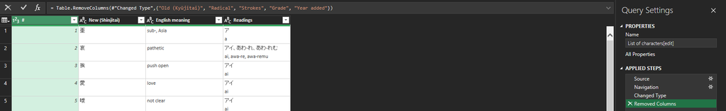

**Storage**

Then, I saved the table as a CSV file to import the table in database I created, called "japanese" in MySQL Workbench.

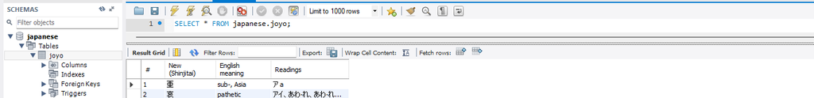

## 2. Vocabulary list from official Japanese exam JLPT N5-4-3-2-1

**Extraction**

From the website https://dondon.media/jlpt-n5-vocabulaire/, I extracted the 5 tables of the JPLT. Then, I used Power Query to append the tables and get only one.

**Storage**

As before, I imported a CSV file to the database.

## 3. Subtitles from the anime "寄生獣" (Parasyte)

**Extraction**

On Netflix, I have chrome extension called Language Reactor where I have different configurations for the subtitles. There is an export option to get the subtitles in an excel file. I did that for the 24 episodes of the anime. (My Netflix account is in French).

[figure not shown]

**Storage**

I had issues to put it in the database, I am not sure why but I think it's because of the Japanese character format of the netflix export. It was not working properly when I tried to import the CSV to MySQL Workbench. It was very random and depended on the line of the table.

To solve this problem, I first used a code to append the 24 tables to 1. Afterwards, I connected my juyper notebook to the databse on MySQL Workbench and inserted the values.

```python
#Create the combined table with the 24 tables

import pandas as pd

# create an empty list to hold the dataframes
df_list = []

# loop through file numbers from 1 to 24
for i in range(1, 25):
    # create the file name string for the current file number
    file_name = str(i) + '.xlsx'
    try:
        # read data from the Excel file into a dataframe
        df = pd.read_excel(file_name)

        # append the dataframe to the list
        df_list.append(df)

    except FileNotFoundError:
        print(f"Warning: File '{file_name}' not found")

# concatenate all dataframes in the list into a single dataframe
combined_df = pd.concat(df_list, axis=0, ignore_index=True)

# save the combined dataframe to an Excel file
combined_df.to_csv('combined.csv', index=False)

# print confirmation message
print('Combined dataframe saved to csv file.')
```

```python
df = pd.read_csv('combined.csv')
#df
```

```python
!pip install mysql-connector-python
```

SQL : **In parallel, I created the table in MySQL with this code :**

CREATE TABLE sub (  
ID INT AUTO_INCREMENT PRIMARY KEY,  
Time VARCHAR(255),  
Subtitle VARCHAR(255),  
Translation VARCHAR(255),  
Romaji VARCHAR(255),  
Hiragana VARCHAR(500)  
);

```python
#Connect the notebook to MySQL Workbench and insert the values in the table sub (: subtitles)

import mysql.connector
from mysql.connector import Error

# read the CSV file into a Pandas DataFrame
df = pd.read_csv('combined.csv')

try:
    # connect to the MySQL database
    connection = mysql.connector.connect(
        host='localhost',
        database='japanese',
        user='root',
        password='*********' #I hid it
    )

    if connection.is_connected():
        # print the MySQL server version and database name
        db_info = connection.get_server_info()
        print(f"Connected to MySQL Server version {db_info}")
        cursor = connection.cursor()
        cursor.execute("select database();")
        record = cursor.fetchone()
        print(f"You're connected to database: {record[0]}")

        # insert the data into the MySQL table
        for index, row in df.iterrows():
            sql = "INSERT INTO sub (Time,Subtitle,Translation,Romaji,Hiragana) VALUES (%s, %s, %s, %s, %s)"
            values = (row['Time'], row['Subtitle'], row['Translation'], row['Romaji'], row['Hiragana'])
            cursor.execute(sql, values)
            connection.commit()

        print(f"{cursor.rowcount} rows inserted into mytable.")

except Error as e:
    print(f"Error while connecting to MySQL: {e}")

finally:
    # close the MySQL connection
    if connection.is_connected():
        cursor.close()
        connection.close()
        print("MySQL connection is closed.")
```

# Step 2 : Clean the data in MySQL

**Remark : I executed SQL Queries from this notebook using Magic SQL.**

In the anime subtitles, there were parts that needed to be removed. As I verified the pareto law, each character/word was taken into account for the entire dataset to analyze the appearing frequence.

For instance :

I love Japanese ♪ = I (1) love (1) Japanese (1) ♪ (1) = 4 words.

If we do a ratio of this sentence like so => "love" represents 25% of the sentence. The character "♪" only indicates a music moment in the Netflix video and it brings no sense to the sentence. By removing it, "love" represents now 33.33% of the sentence, which makes a huge difference for my Pareto analysis. It's obvious to remove this character but for some other ones it's not that easy.

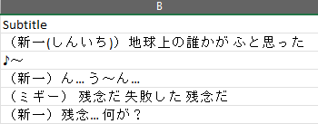

What I removed :

- "♪～"
- Everything between "()" as it represented names or Kanji pronunciation
- "..." : it's a tough one in terms of meaning => sometimes it represents an hesitation of the character speaking which creates duplicaion. For instance : I...I love Japanese. If I remove "...", we have this sentence in the table -> I I love you. "I" appears twice meanwhile in the true meaning it should be once. I cannot removed the word just before "..." because it could be just to make the sentence longer on Netflix (e.g "I love...Japanese"). I decided to remove the "...", let the characters even in double and assumed the repetition would be something important verbally to understand an hesitation. I did not remove it directly with SQL queries in the database but afterwards in a python dataframe.

```python
# Set Magic SQL

!pip install ipython-sql

!pip install pymysql
```

```python
# connect to the MySQL database
%load_ext sql
%sql mysql+pymysql://root:*******localhost/japanese
```

```python
%%sql # ALL SQL QUERIES

#--------------------------------------

# Remove the columns that I do not need

# ALTER TABLE sub
# DROP COLUMN Time
# DROP COLUMN Translation,
# DROP COLUMN Romaji,
# DROP COLUMN Hiragana;

#--------------------------------------

# Remove the characters ♪～

# UPDATE sub
# SET Subtitle = REPLACE(Subtitle, '♪～', '')
# WHERE Subtitle LIKE '%♪～%';
# SELECT * FROM sub WHERE Subtitle LIKE '%♪%';

#--------------------------------------

# Remove the everything inside the parenthesis and the parenthesis themselves : important, the parenthesis are wih a chinese format and not the standard one.

# UPDATE sub
# SET Subtitle = REGEXP_REPLACE(Subtitle, '（.*）', '');

#--------------------------------------

# Remove the white spaces

# UPDATE sub SET Subtitle = REPLACE(Subtitle, ' ', '');

#--------------------------------------

# Count the numbers of character and do a Sum : Char_Length has to be used as it is for japanese characters -> Total_length = 80165 characters

# SELECT SUM(CHAR_LENGTH(Subtitle)) AS total_length FROM sub;

SELECT * FROM sub WHERE Subtitle LIKE '%女の子%';
```

# Step 3 : Analysis of the word occurences

I used the Mecab librairy to identify the different words in Japanese. I also created a CSV file at this moment of the project to visualize all the words in a word network (the word usage and links, see full explaination at step 6 visualization) on POWER BI.

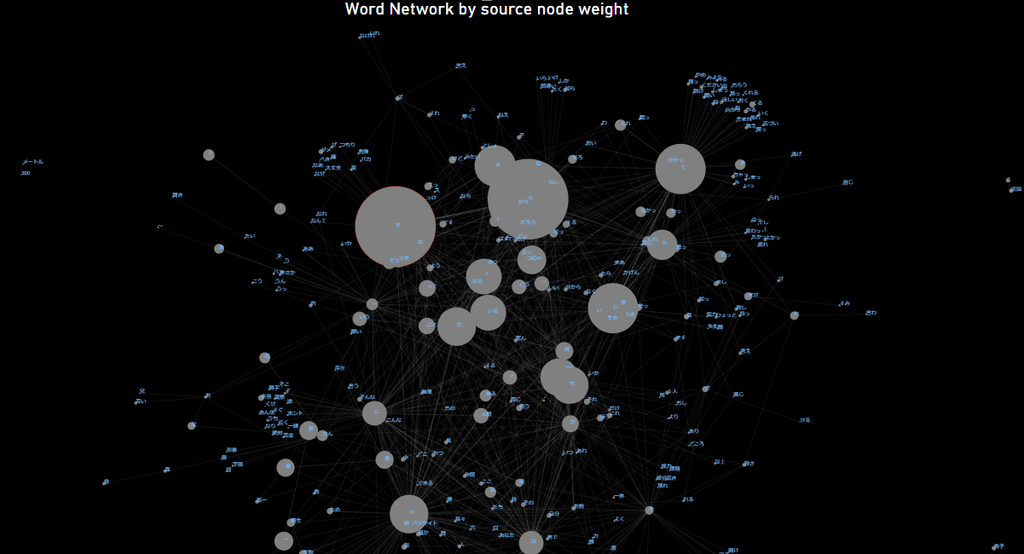

```python
#Store the subtitles into a DataFrame

result = %sql SELECT * FROM sub
df = result.DataFrame()
```

```python
!pip install mecab-python3
!pip install unidic-lite
```

```python
#Creation of the csv file to visualize the word neutwork in POWER BI

import csv
from collections import defaultdict
import MeCab
import pandas as pd

# Initialize MeCab
m = MeCab.Tagger("-Owakati")

# Create a defaultdict to store word connections
word_connections = defaultdict(int)

# Iterate over each subtitle in the DataFrame
for subtitle in df['Subtitle']:
    # Tokenize the subtitle into individual words
    words = m.parse(subtitle).split()

    # Iterate over each word in the subtitle
    for i in range(len(words) - 1):
        # Increment the connection count between two consecutive words
        word_connections[(words[i], words[i+1])] += 1

# Define the CSV file path
csv_file_path = 'word_connections.csv'

# Save the word connections to a CSV file
with open(csv_file_path, 'w', newline='', encoding='utf-8') as csvfile:
    writer = csv.writer(csvfile)
    writer.writerow(['Source', 'Target', 'Weight'])  # Write the header row

    # Write each word connection and its weight
    for (word1, word2), weight in word_connections.items():
        writer.writerow([word1, word2, weight])

print("Word connections saved to CSV:", csv_file_path)
```

```python
#Creation of the a datframe taking all the different words indentified with the MeCab librairy

# Iterate over each subtitle in the DataFrame
words_list = []
for subtitle in df['Subtitle']:
    # Tokenize the subtitle into individual words
    words = m.parse(subtitle).split()
    words_list.extend(words)

# Create a DataFrame with the words------------------>  50322 words
df_words = pd.DataFrame({'Words': words_list})
```

I had 50322 words. Regarding the pareto principle :

- 80%(words) = 0.8 * 50322 = 40258 words
- 20%(words) = 0.2 * 50322 = 10064 words

Here, when I printed all the words and their frequency, I noticed that some characters were appearing a lot.

This was likely to happen because in Japanese with some key words called "particles". Without entering into the details, an example is the particle "は" that expresses the theme of the sentence. It appears 1499 times over 10064 (the 20% most used words).

We can already draw an important conclusion : **The particles are essential to understand Japanese, let's consider them as a block instead of separate words. This means, the most import thing is learning the particle regarding the frequency.**

To get an idea of what are the main particles :

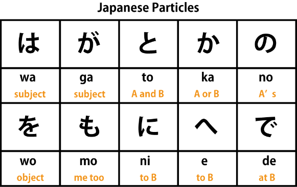

And what appears as the most frequent words :

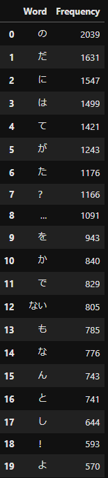

It was obvious that I needed to take them off of the study. What's more, the punctuation needed to be removed too. I also cleaned some words that appeared too much. I won't explain as it is technical Japanese but an example would be "ない" that represents the negation.

```python
# Words to remove
words_to_remove = ['が', 'の', 'を', 'に', 'へ', 'と', 'で', 'から','まで', 'ない', 'て', '？', '！', 'よ', 'な', 'ん', 'し','…','も','だ','は','ね','た','か','お','じゃ','ば','って','ハハハ']

# Create a boolean mask for rows containing the words to remove
mask = df_words['Words'].isin(words_to_remove)

# Filter the DataFrame using the mask to delete the rows
df_clean = df_words[~mask]

# Reset the index if needed
df_clean.reset_index(drop=True, inplace=True)



# Calculate the total number of words in the cleaned DataFrame
total_words = len(df_clean)

# 27696 words -----------------------> 80%(Words) = 22157 words ; 20% = 5539 words

# Calculate the percentage of occurrence for each word
word_frequency = df_clean['Words'].value_counts().reset_index()
word_frequency.columns = ['Word', 'Frequency']
word_frequency['Percentage'] = (word_frequency['Frequency'] / total_words) * 100

# Calculate the cumulative frequency of occurrence
word_frequency['Cumulative Frequency'] = word_frequency['Frequency'].cumsum()


# Calculate the cumulative percentage of occurrence
word_frequency['Cumulative Percentage'] = word_frequency['Percentage'].cumsum()


# word_frequency => 4029 words : 20% = 806 words ; 80%=

# Print word_frequency where the cumulative percentage is less than 80

print(word_frequency[word_frequency['Cumulative Percentage'] < 80])
```

**Moment of truth...**

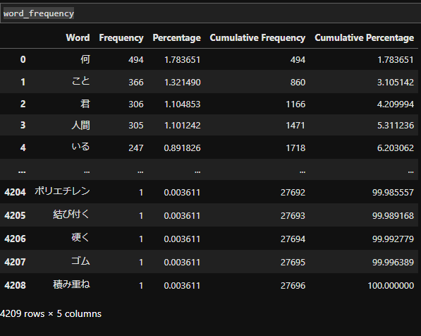

When we remove (['が', 'の', 'を', 'に', 'へ', 'と', 'で', 'から','まで', 'ない', 'て', '？', '！', 'よ', 'な', 'ん', 'し','…','も','だ','は','ね','た','か','お','じゃ','ば','って','ハハハ']) :

- The punctation
- The particles that are the first thing to focus on because they appear a lot
- Some basic characters

=> Over 27696 words (in total), 80% of it can be understood with unique 897 words with a cumulated fequency of 22156 words.

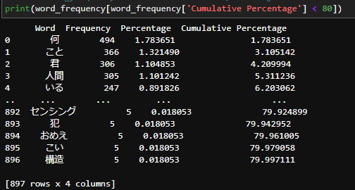

Considering the potential words that need still to be cleaned and the pareto principle that is ABOUT 80-20 :

**The study is validated. Learning 20% of the (most used) unique words makes possible to understand 80% of the subtitles in the serie.**

[figure not shown]

# Step 4 : Comparison with the vocabulary of the JLPT

The idea is the same :

- Taking all the JLPT words from level 1 to 5, see if our previous list of 20% most represent 20% of the JLPT vocabulary. Not only in terms of number but also in terms of matches (if the 20% of words in the serie are also representing 20% of the words in the JLPT. It can different for instance if the words in the serie are very specific and the words are not commonly learned/used).

```python
voc = %sql SELECT * FROM vocabulary
df_voc = voc.DataFrame() # 5482 rows × 5 columns

Most_important=word_frequency[word_frequency['Cumulative Percentage'] <= 80]

Most_important
```

```python
# Count occurrences of words in Kanji column
word_count_kanji = df_voc['Kanji'].value_counts()

# Create a new column in word_frequency to store the count
Most_important['Word_Count_JLPT_Kanji'] = Most_important['Word'].map(word_count_kanji)

# Count occurrences of words in Kanji column
word_count_kana = df_voc['Kana'].value_counts()

# Create a new column in word_frequency to store the count
Most_important['Word_Count_JLPT_Kana'] = Most_important['Word'].map(word_count_kana)



# Display the updated word_frequency dataframe
Most_important[['Word_Count_JLPT_Kanji','Word_Count_JLPT_Kana']]

Most_important['JLPT_Frequence'] = Most_important[['Word_Count_JLPT_Kanji', 'Word_Count_JLPT_Kana']].sum(axis=1)
```

```python
#Count the number of times that the unique words in word_frequency appear in Kanji Or Kana -> 1909 times
Most_important['JLPT_Frequence'].sum()
```

```python
Most_important.to_csv('most_important_words.csv', index=False)
```

This means that over 5482 values in the JLPT, the most important words of the Netflix serie represent :

- In the serie, 654 words (over the 897 most important) appear in the JLPT list -> (654/5482)*100 = 12% of the words.
- With the previous results -> (897/5482)*100 = 16% of the words.

Considering the noise in the .map() method and the values not too far from 20% ->

**~20% of the vocabulary (about more or less 900 words) allow to understand 80% of the content of the Netflix serie. Reagrding the JLPT vocabulary, it concerncs ~ between 12% and 16% of the total (Pareto principle ok)**.

# Step 5 : Comparison with the Jôyô Kanji list

This analysis is slightly different because only the Kanji are necessary and not the hirigana and katakana.

As 1 kanji = 1 character, it's way easier to extract them from the dataset and study it.

```python
jo = %sql SELECT * FROM joyo
df_jo = jo.DataFrame() # 2136 rows
df_jo
```

```python
pip install regex
```

```python
import regex

def extract_kanji(text):
    kanji_pattern = regex.compile(r'\p{Script=Han}')
    kanji_characters = kanji_pattern.findall(text)
    return kanji_characters

# Apply the count_kanji function to the 'Subtitle' column and flatten the resulting list
kanji_list = df['Subtitle'].apply(extract_kanji).explode()

# Count the frequency of each Kanji character
kanji_frequency = kanji_list.value_counts().reset_index()

# Rename the columns
kanji_frequency.columns = ['Kanji', 'Frequency']

# Calculate cumulated frequency and percentage
kanji_frequency['Cumulated_Frequency'] = kanji_frequency['Frequency'].cumsum()
kanji_frequency['Percentage'] = kanji_frequency['Frequency'] / kanji_frequency['Frequency'].sum() * 100
kanji_frequency['Cumulated_Percentage'] = kanji_frequency['Percentage'].cumsum()

# Display the resulting DataFrame
kanji_frequency

#This line has been added after to remove this "parasyte" kanji.
kanji_frequency = kanji_frequency.drop(kanji_frequency[kanji_frequency['Kanji'] == '々'].index)
```

```python
Most_important_kanji = kanji_frequency[kanji_frequency['Cumulated_Percentage'] <=80]

Most_important_kanji
```

In all the Kanji of the serie, 80% of the occurences are made by 290 Kanji : 290/1200*100= 24%

Pareto principle -> Validated.

Let's check in the Jôyô Kanji list if we found all the 290 Kanji.

```python
# Count the occurrences of each Kanji in the "New (Shinjitai)" column
kanji_counts = df_jo['New (Shinjitai)'].value_counts()

# Create a new column in Most_important_kanji to store the counts
Most_important_kanji['Count'] = Most_important_kanji['Kanji'].map(kanji_counts)
```

```python
# Print the updated Most_important_kanji dataframe
Most_important_kanji['Count'].sum()

#Check the values not in the Jôyô Kanji
Most_important_kanji[Most_important_kanji['Count'].isnull()] #-> 288 Kanji
```

288 Kanji of the series are in the Joyo list. 2 of them are not : 々 (which a repetition mark) and 玲 (which for information means "sound of jewels", with a frequency = 0.099985%). I removed the 々 as we can consider it not as a Kanji per se.

To conclude :

- The 290 Kanji that represents 80% of the serie Kanji are all present in the Jôyo list expect one.
- 289/2136*100 = 13.5% of the Jôyô list represent about 80% of the kanji in the serie.

Remark 20% of the Jôyô list = 427 Kanji.

```python
Most_important_kanji.to_csv('most_important_kanji.csv', index=False)
```

## General conclusion : The Pareto Principle is validated.

**Words :**

Remark : Some potential noise/issues can make some variations on this resultat with way the words are identified in the MeCab module.The reliability or accuracy of the MeCab module depends on various factors, including the quality of the underlying dictionary, the specific configuration settings used, and the context in which it is applied. MeCab is a widely used morphological analysis tool for the Japanese language, and it has been developed and refined over many years.

**This data analysis illustrates well the Pareto Principle 80-20 : about 20% the words allow to understand 80% of the words that appear. However, it does not mean necessarily to understand 80% of the meaning as sometimes 100% of the words are necessary to understand a text. Furthermore, depending on the serie and the context, these list of words and Kanji can vary. It is still a good approach to focus on what's important to understand a large part of words in a serie instead of trying to learn everything at once.**

To see the full vizualisation on Power BI, open the file .bi

# Step 6 : Visualization

To see the full vizualisation anmiation on Power BI, open the file netwrok.pbix

1- Extract of the word network with all the words (including the particles) : This represents how the words are linked to each other in the serie. It's easy to spot what words are outstanding in this representation. The bigger the circle, the more the word is used and link to the other words. It's logical to have the particle such as の in a big circle and link to a lot of words.

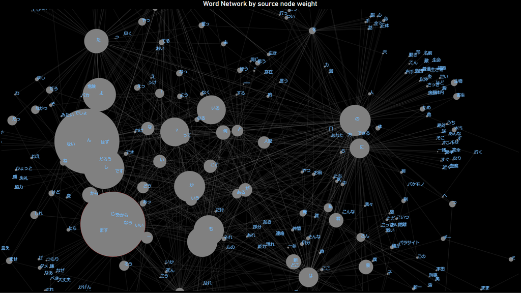

2- 80% of the most used words : This represents the 20% of words that lead to 80% of usage in the serie. A constellation of words shows how much the words appears by sizing the circles in function of the frequence.There are filters to change the percentage of words (to see for example if we want to understand 50% of the words in the serie, how many words it represents).

A first important observation is that some circles are outstanding but most of them have a quite similar size -> The 80% of the most used words are composed of several values that do not appear frequently.

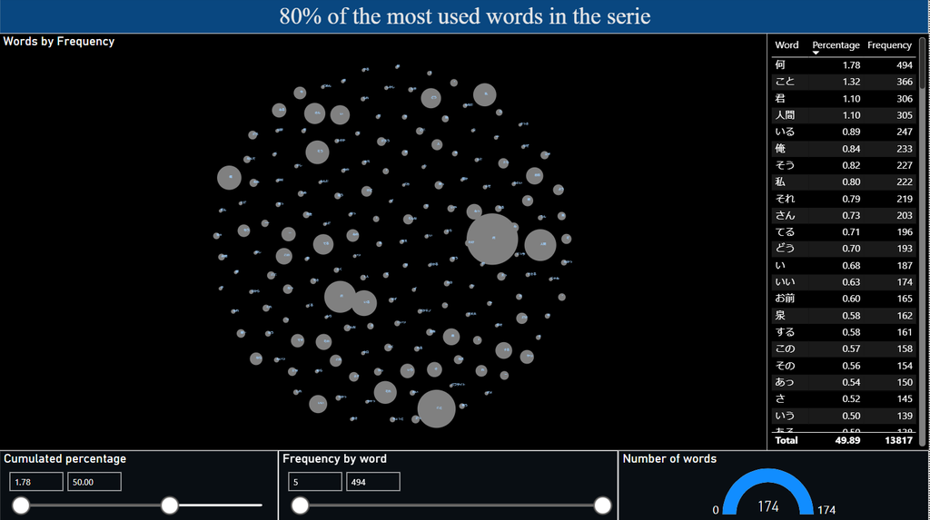

3-80% of the most used kanji : This represents the 20% of kanjithat lead to 80% of usage in the serie. A treemap displays the frequency by kanji. They is a filter to change the cumulated percentage (to see for example if we want to understand 25% of the words in the serie, how many words it represents).

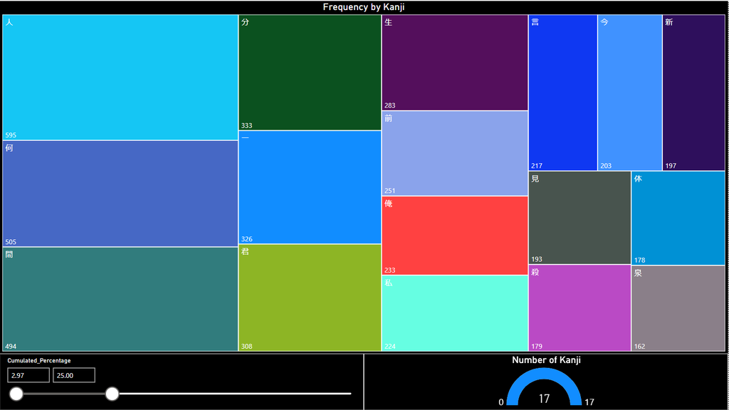